# Assignment 1

Jiansong Xu

January 18, 2019

```r
library(binom)
library(dplyr)
```

# Lecture 3

1. There are n identical trails. This is satisfied, since each observation was recorded at the same town, same intersection, within one-half an hour time range.
2. There are 2 possible outcomes. This is satisfied, because the car is either alternative fuel using or not.
3. Each trail is independent to others. This condition is satisfied, because the type of one car does not affect the type of next car being observed.
4. The possibility of success remains constant through trails. This condition holds, because this is not likely to be affected by excluded measures.
5. The random variable of interest W is number of success. Satisfied, in this experiment , W=14.

```r
alpha <- 0.05
w <- 14
n <- 125
chop <- c("agresti-coull", "asymptotic", "wilson", "exact")
binom.confint(x = w, n = n, conf.level = 1-alpha, methods = "all") %>% filter(method %in% chop) -> CI1
print(CI1)
```

```
##          method  x   n  mean      lower     upper
## 1 agresti-coull 14 125 0.112 0.06674422 0.1803925
## 2    asymptotic 14 125 0.112 0.05671484 0.1672852
## 3         exact 14 125 0.112 0.06260138 0.1807736
## 4        wilson 14 125 0.112 0.06789839 0.1792384
```

3. Use 2-sided Score test H0: pi = 0.08 Ha: pi != 0.08

```r
pi.0 = 0.08
prop.test(x=w, n=n, p = pi.0, alternative="two.sided", correct=FALSE) #2-sided Score test
```

```
##
##  1-sample proportions test without continuity correction
##
## data:  w out of n, null probability pi.0
## X-squared = 1.7391, df = 1, p-value = 0.1872
## alternative hypothesis: true p is not equal to 0.08
## 95 percent confidence interval:
##  0.06789839 0.17923836
## sample estimates:
##     p
## 0.112
```

We fail to reject H0, so we cannot conclude the probability in this intersection is differ from nationwide probability.

```r
alpha <- 0.05
w2 <- 79
n2 <- 80
pi.hat2 <- w2/n2
var.pi.hat2 <- pi.hat2*(1-pi.hat2)/n
pi2.0 = 1
```

```r
binom.confint(x = w2, n = n2, conf.level = 1-alpha, methods = "asymptotic")
```

|  | method | x | n | mean | lower | upper |
| --- | --- | --- | --- | --- | --- | --- |
| 1 | asymptotic | 79 | 80 | 0.9875 | 0.9631541 | 1.011846 |

Wald CI: [0.963 - 1.011]. We except 95% of similarly constructed intervals to contain the true probability of a randomly selected resident to oppose the tax.

```r
binom.confint(x = w2, n = n2, conf.level = 1-alpha, methods = "wilson")
```

|  | method | x | n | mean | lower | upper |
| --- | --- | --- | --- | --- | --- | --- |
| 1 | wilson | 79 | 80 | 0.9875 | 0.9325373 | 0.99779 |

Wilson CI: [0.933 - 0.998]. We expect 95% of similarly constructed intervals to contain the parameter pi which represents the true probability of a randomly selected resident to oppose the tax.

3. We can testify this by performing Score test. H0: pi = 1, Ha: pi < 1

```r
(Z0 = (pi.hat2 - pi2.0)/sqrt(0.5*0.5/n2))
```

```
## [1] -0.2236068
```

```r
(pv.score <- pnorm(Z0)) #lower tail p-value
```

```
## [1] 0.4115316
```

Base on p value we fail to reject H0, so it is possible for pi = 1.

4. I prefer the Wilson CI, as it is constructed using the pi from null hypothesis instead of sample, and the sample size is rather small in this case, so Wilson would perform better.

```r
n.L <- 1000 #large sample
n.S <- 10 #small sample
w.L <- 0:n.L
w.S <- 0:n.S
```

*Large sample*

```r
CI.L <- binom.confint(x = w.L, n = n.L, conf.level = 1-alpha, methods = c("asymptotic", "agresti-coull", "wilson", "exact"))
head(CI.L.wald <- filter(CI.L, method == "asymptotic"))#Wald CIs
```

|  | method | x | n | mean | lower | upper |
| --- | --- | --- | --- | --- | --- | --- |
| 1 | asymptotic | 0 | 1000 | 0.000 | 0.000000e+00 | 0.000000000 |
| 2 | asymptotic | 1 | 1000 | 0.001 | -9.589838e-04 | 0.002958984 |
| 3 | asymptotic | 2 | 1000 | 0.002 | -7.690345e-04 | 0.004769034 |
| 4 | asymptotic | 3 | 1000 | 0.003 | -3.896612e-04 | 0.006389661 |
| 5 | asymptotic | 4 | 1000 | 0.004 | 8.791974e-05 | 0.007912080 |
| 6 | asymptotic | 5 | 1000 | 0.005 | 6.283576e-04 | 0.009371642 |

```r
head(CI.L.ac <- filter(CI.L, method =="agresti-coull"))#agresti-coill CIs
```

|  | method | x | n | mean | lower | upper |
| --- | --- | --- | --- | --- | --- | --- |
| 1 | agresti-coull | 0 | 1000 | 0.000 | -7.899577e-04 | 0.004616716 |
| 2 | agresti-coull | 1 | 1000 | 0.001 | -4.223778e-04 | 0.006241483 |
| 3 | agresti-coull | 2 | 1000 | 0.002 | 4.724247e-05 | 0.007764209 |
| 4 | agresti-coull | 3 | 1000 | 0.003 | 5.814324e-04 | 0.009222366 |
| 5 | agresti-coull | 4 | 1000 | 0.004 | 1.161262e-03 | 0.010634883 |
| 6 | agresti-coull | 5 | 1000 | 0.005 | 1.775581e-03 | 0.012012910 |

```r
head(CI.L.s <- filter(CI.L, method == "wilson"))#score CIs
```

|  | method | x | n | mean | lower | upper |
| --- | --- | --- | --- | --- | --- | --- |
| 1 | wilson | 0 | 1000 | 0.000 | 2.160106e-19 | 0.003826758 |
| 2 | wilson | 1 | 1000 | 0.001 | 1.765464e-04 | 0.005642559 |
| 3 | wilson | 2 | 1000 | 0.002 | 5.486436e-04 | 0.007262808 |
| 4 | wilson | 3 | 1000 | 0.003 | 1.020784e-03 | 0.008783014 |
| 5 | wilson | 4 | 1000 | 0.004 | 1.556588e-03 | 0.010239556 |
| 6 | wilson | 5 | 1000 | 0.005 | 2.137536e-03 | 0.011650955 |

```r
head(CI.L.cp <- filter(CI.L, method == "exact"))#clopper-pearson CIs
```

|  | method | x | n | mean | lower | upper |
| --- | --- | --- | --- | --- | --- | --- |
| 1 | exact | 0 | 1000 | 0.000 | 0.000000e+00 | 0.003682084 |
| 2 | exact | 1 | 1000 | 0.001 | 2.531749e-05 | 0.005558924 |
| 3 | exact | 2 | 1000 | 0.002 | 2.423011e-04 | 0.007205839 |
| 4 | exact | 3 | 1000 | 0.003 | 6.190999e-04 | 0.008742023 |
| 5 | exact | 4 | 1000 | 0.004 | 1.090908e-03 | 0.010209665 |
| 6 | exact | 5 | 1000 | 0.005 | 1.625420e-03 | 0.011629471 |

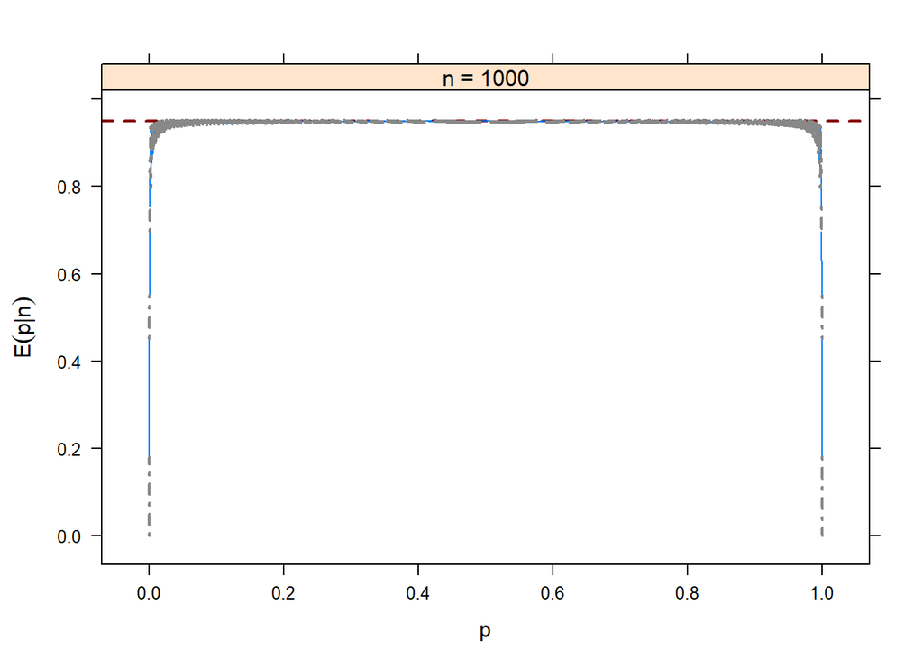

```r
binom.plot(n = 1000, method = binom.asymp, np = 5000, conf.level = 0.95)
```

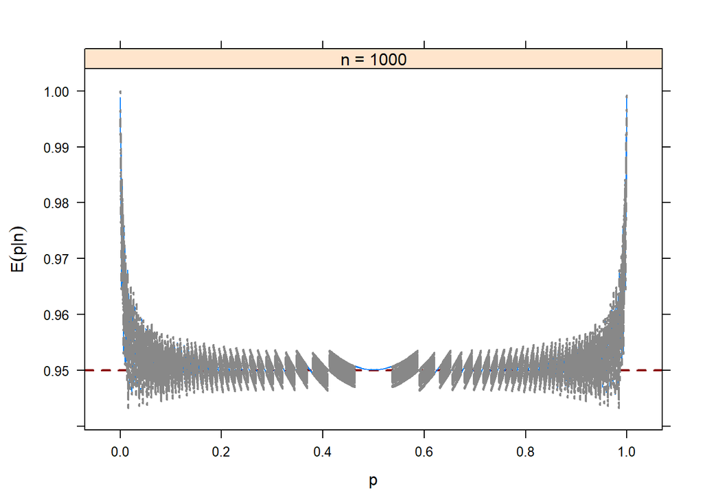

```r
binom.plot(n = 1000, method = binom.agresti.coull, np = 5000, conf.level = 0.95)
```

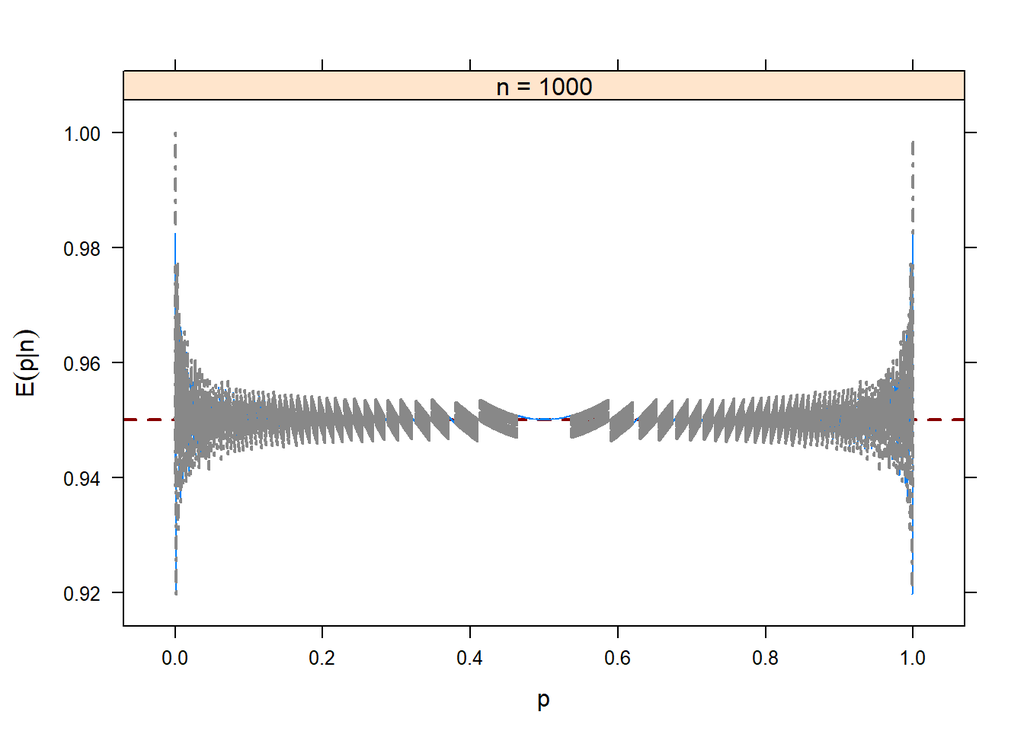

```r
binom.plot(n = 1000, method = binom.wilson, np = 5000, conf.level = 0.95)
```

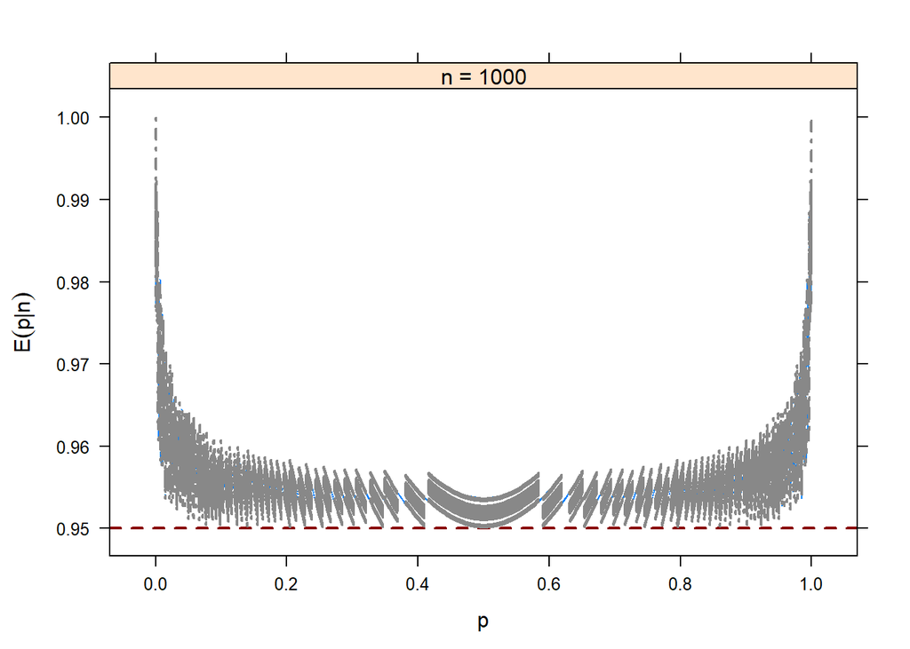

```r
binom.plot(n = 1000, method = binom.exact, np = 5000, conf.level = 0.95)
```

```r
#Small sample
CI.S <- binom.confint(x=w.S, n=n.S, conf.level = 1-alpha, methods = c("asymptotic", "agresti-coull", "wilson", "exact"))
head(filter(CI.S, method == "asymptotic"))#wald CIs
```

|  | method | x | n | mean | lower | upper |
| --- | --- | --- | --- | --- | --- | --- |
| 1 | asymptotic | 0 | 10 | 0.0 | 0.00000000 | 0.0000000 |
| 2 | asymptotic | 1 | 10 | 0.1 | -0.08593851 | 0.2859385 |
| 3 | asymptotic | 2 | 10 | 0.2 | -0.04791801 | 0.4479180 |
| 4 | asymptotic | 3 | 10 | 0.3 | 0.01597423 | 0.5840258 |
| 5 | asymptotic | 4 | 10 | 0.4 | 0.09636369 | 0.7036363 |
| 6 | asymptotic | 5 | 10 | 0.5 | 0.19010248 | 0.8098975 |

```r
head(filter(CI.S, method == "agresti-coull"))#agresti-coull CIS
```

|  | method | x | n | mean | lower | upper |
| --- | --- | --- | --- | --- | --- | --- |
| 1 | agresti-coull | 0 | 10 | 0.0 | -0.043354506 | 0.3208873 |
| 2 | agresti-coull | 1 | 10 | 0.1 | -0.003941498 | 0.4259677 |
| 3 | agresti-coull | 2 | 10 | 0.2 | 0.045887270 | 0.5206324 |
| 4 | agresti-coull | 3 | 10 | 0.3 | 0.103338418 | 0.6076747 |
| 5 | agresti-coull | 4 | 10 | 0.4 | 0.167110626 | 0.6883959 |
| 6 | agresti-coull | 5 | 10 | 0.5 | 0.236593091 | 0.7634069 |

```r
head(filter(CI.S, method == "wilson"))#score CIs
```

|  | method | x | n | mean | lower | upper |
| --- | --- | --- | --- | --- | --- | --- |
| 1 | wilson | 0 | 10 | 0.0 | 2.005249e-17 | 0.2775328 |
| 2 | wilson | 1 | 10 | 0.1 | 1.787621e-02 | 0.4041500 |
| 3 | wilson | 2 | 10 | 0.2 | 5.668215e-02 | 0.5098375 |
| 4 | wilson | 3 | 10 | 0.3 | 1.077913e-01 | 0.6032219 |
| 5 | wilson | 4 | 10 | 0.4 | 1.681803e-01 | 0.6873262 |
| 6 | wilson | 5 | 10 | 0.5 | 2.365931e-01 | 0.7634069 |

```r
head(filter(CI.S, method == "exact"))#clopper-pearson CIS
```

|  | method | x | n | mean | lower | upper |
| --- | --- | --- | --- | --- | --- | --- |
| 1 | exact | 0 | 10 | 0.0 | 0.000000000 | 0.3084971 |
| 2 | exact | 1 | 10 | 0.1 | 0.002528579 | 0.4450161 |
| 3 | exact | 2 | 10 | 0.2 | 0.025210726 | 0.5560955 |
| 4 | exact | 3 | 10 | 0.3 | 0.066739511 | 0.6524529 |
| 5 | exact | 4 | 10 | 0.4 | 0.121552258 | 0.7376219 |
| 6 | exact | 5 | 10 | 0.5 | 0.187086028 | 0.8129140 |

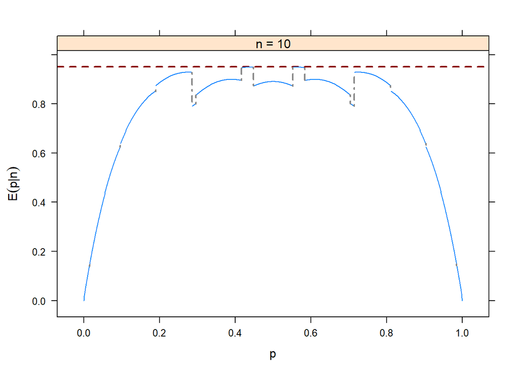

```r
binom.plot(n = 10, method = binom.asymp, np = 1000, conf.level = 0.95)
```

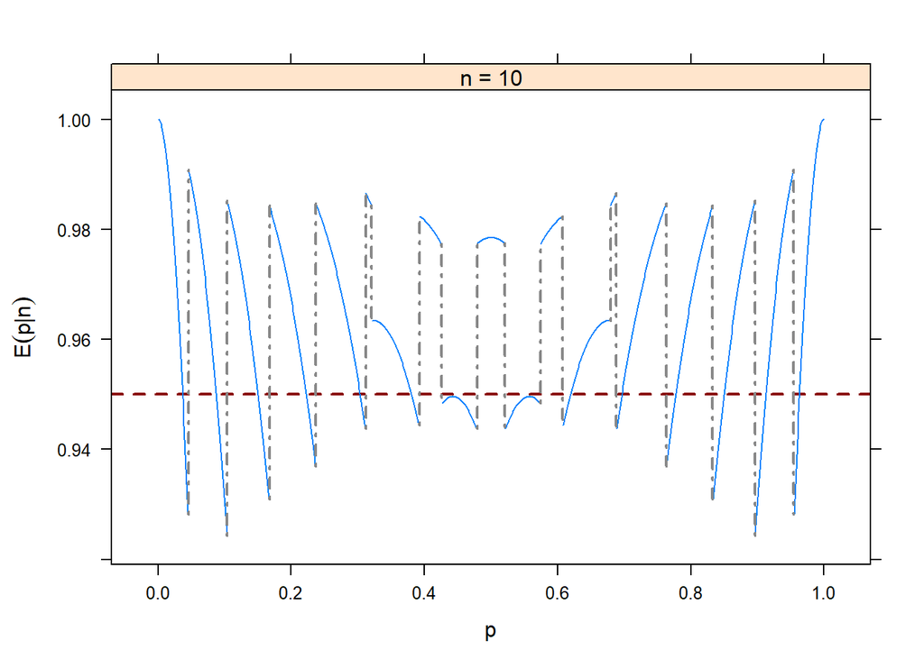

```r
binom.plot(n = 10, method = binom.agresti.coull, np = 1000, conf.level = 0.95)
```

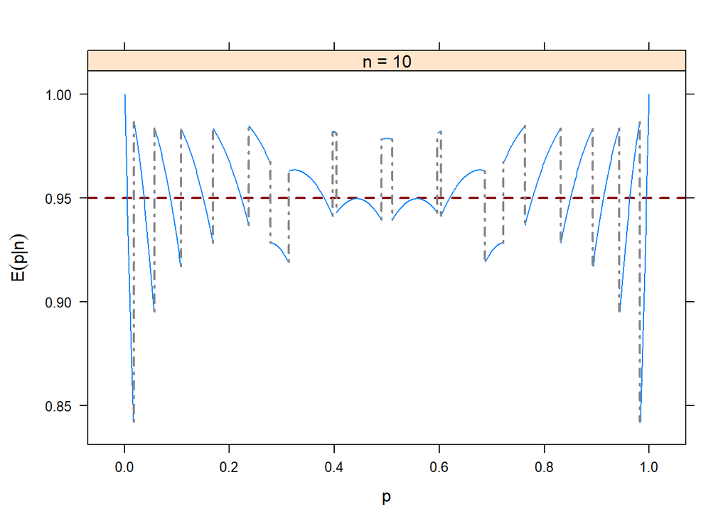

```r
binom.plot(n = 10, method = binom.wilson, np = 1000, conf.level = 0.95)
```

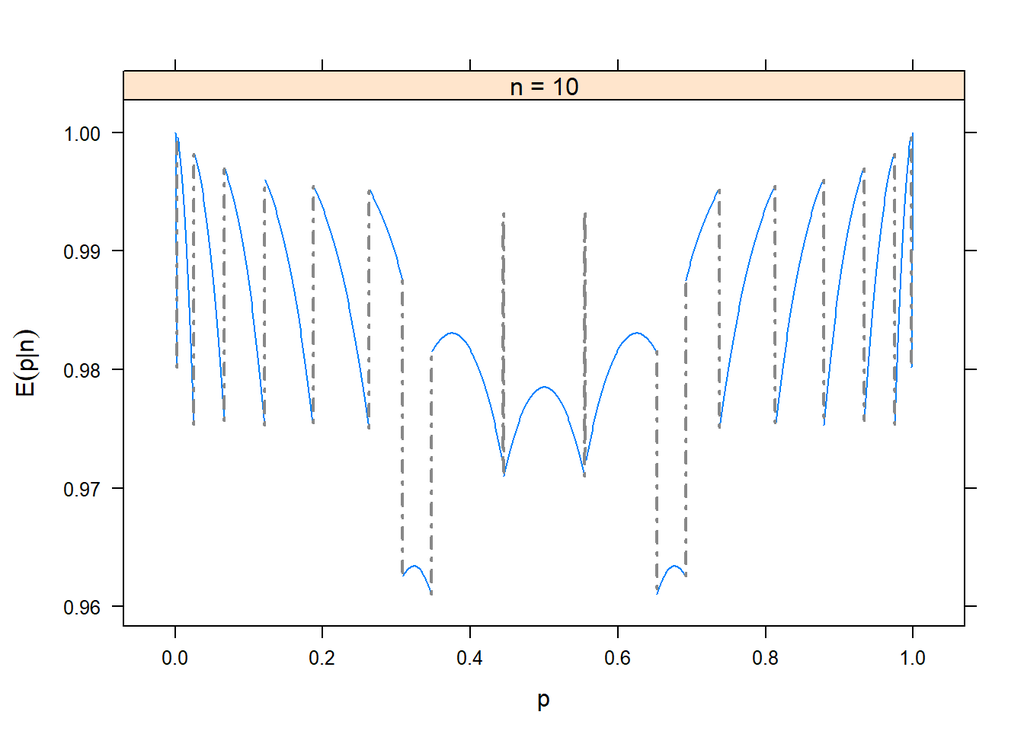

```r
binom.plot(n = 10, method = binom.exact, np = 1000, conf.level = 0.95)
```

2. For large sample size, the patterns of coverage seem to behave well with minor differences among different methods. However with small sample, comparing to large sample, the curves are less likely to stay along the .95 line(this is very obvious in graphs for wald and clopper-pearson), which means the CIs are less likely to guarantee having 95% confident level when dealing with small sample.

# Lecture 4

```r
library(PropCIs)
alpha <- 0.05

#Time-out group
w.v <- 10
n.v <- 16
#No Time-out group
w.p <- 22
n.p <- 26
```

```r
wald2ci(x1=w.v, n1=n.v, x2=w.p, n2=n.p, conf.level = 0.95, adjust = "Wald")
```

```
##
##
##
## data:
##
## 95 percent confidence interval:
##  -0.49593538  0.05362769
## sample estimates:
## [1] -0.2211538
```

```r
wald2ci(x1=w.v, n1=n.v, x2=w.p, n2=n.p, conf.level = 0.95, adjust = "AC")
```

```
##
##
##
## data:
##
## 95 percent confidence interval:
##  -0.47648115  0.05584623
## sample estimates:
## [1] -0.2103175
```

```r
diffscoreci(x1=w.v, n1=n.v, x2=w.p, n2=n.p, conf.level = 0.95)
```

```
##
##
##
## data:
##
## 95 percent confidence interval:
##  -0.49174585  0.04592923
```

For each type of interval: we expect 95% of all similarly constructed intervals to contain the true value of the difference between probabilities of success of 2 strategy groups.

```r
#score
prop.test(x=c(w.v, w.p), n=c(n.v, n.p), alternative="less", correct=FALSE)
```

```
##
##  2-sample test for equality of proportions without continuity
##  correction
##
## data:  c(w.v, w.p) out of c(n.v, n.p)
## X-squared = 2.6704, df = 1, p-value = 0.05111
## alternative hypothesis: less
## 95 percent confidence interval:
##  -1.000000000  0.009450086
## sample estimates:
##    prop 1    prop 2
## 0.6250000 0.8461538
```

Based on large p value, we fail to reject H0: pi1 = pi2.

```r
#LR
kicmat <- matrix(data=c(w.v, w.p, n.v-w.v, n.p-w.p), nrow=2)
library(vcd)
assocstats(kicmat)
```

```
##                     X^2 df P(> X^2)
## Likelihood Ratio 2.6106  1  0.10615
## Pearson          2.6704  1  0.10223
##
## Phi-Coefficient   : 0.252
## Contingency Coeff.: 0.245
## Cramer's V        : 0.252
```

We cannot reject H0 using LR test, as p value is greater than alpha = 0.05.

```r
#Non-native group
w.v2 <- 118
n.v2 <- 211

#Native group
w.p2 <- 155
n.p2 <- 206
```

H0: pi1 - pi2 = 0  
Ha: pi1 - pi1 < 0 alpha = 0.05

Use score test

```r
prop.test(x=c(w.v2, w.p2), n=c(n.v2, n.p2), alternative="less", correct=FALSE)
```

```
##
##  2-sample test for equality of proportions without continuity
##  correction
##
## data:  c(w.v2, w.p2) out of c(n.v2, n.p2)
## X-squared = 17.207, df = 1, p-value = 1.676e-05
## alternative hypothesis: less
## 95 percent confidence interval:
##  -1.0000000 -0.1183044
## sample estimates:
##    prop 1    prop 2
## 0.5592417 0.7524272
```

We reject H0 because p value is smaller than alpha. So we conclude that non-native English speaking students do not pick up on humor as much as native English speaking stduents.

# Leture 5

```r
#Time-out group
w.v <- 10
n.v <- 16
# No Time-out group
w.p <- 22
n.p <- 26
```

```r
pi.hat.v <- w.v/n.v
pi.hat.p <- w.p/n.p
pi.hat.v/pi.hat.p #Relative risk
```

```
## [1] 0.7386364
```

The success rate of time-out group is 0.7386 times as high as the no time-out group.

```r
riskscoreci(x1=w.v, n1=n.v, x2=w.p, n2=n.p, conf.level = 0.95) #Score CI
```

```
##
##
##
## data:
##
## 95 percent confidence interval:
##  0.4480251 1.0600376
```

We expect 95% of similarly constructed intervels to contain the true relative risk of the time-out group to make a successful kick.

```r
(w.v * (n.p-w.p)) / (w.p * (n.v-w.v)) #Odds Ratio
```

```
## [1] 0.3030303
```

The odds of making a successful kick of time-out group are 0.3030 times as high as they are in no time-out group.

```r
orscoreci(x1=w.v, n1=n.v, x2=w.p, n2=n.p, conf.level = 0.95) #Score CI of odds ratio
```

```
##
##
##
## data:
##
## 95 percent confidence interval:
##  0.0726889 1.2696219
```

We expect 95% of all similarly constructed intervals to contain the odds ratio between 2 groups.

5. Use Score test to testify whether 2 groups have the same rate of success. H0: pi1 - pi2 = 0, Ha: pi1 - pi2 < 0, alpha = 0.05.

```r
prop.test(x=c(w.v, w.p), n=c(n.v, n.p), alternative="less", correct=FALSE)
```

```
##
##  2-sample test for equality of proportions without continuity
##  correction
##
## data:  c(w.v, w.p) out of c(n.v, n.p)
## X-squared = 2.6704, df = 1, p-value = 0.05111
## alternative hypothesis: less
## 95 percent confidence interval:
##  -1.000000000  0.009450086
## sample estimates:
##    prop 1    prop 2
## 0.6250000 0.8461538
```

Based on p value we do not reject null hypothesis, so icing the kicker may not be a good stategy, but the sample sizes are small, so there may exist bias.